# Modeling relational event networks with remstimate

A tutorial

The aim of the function `remstimate()` is to find the set of model parameters that optimizes either: (1) the likelihood function given the observed data or (2) the posterior probability of the parameters given the prior information on their distribution and the likelihood of the data. Furthermore, the likelihood function may differ depending on the modeling framework used, be it tie-oriented or actor-oriented:

- the **tie-oriented** framework, which models the occurrence of dyadic events as realization of ties along with their waiting time (Butts 2008);
- the **actor-oriented** framework, which models the occurrence of the dyadic events as a two-steps process (Stadtfeld and Block 2017):
  1. in the first step, it models the propensity of any actor to initiate any form of interaction as a sender and the waiting time to the next interaction (sender rate model);
  2. in the second step, it models the probability of the sender at 1. choosing the receiver of its future interaction (receiver choice model).

The mandatory input arguments of `remstimate()` are:

- `reh`, which is a `remify` object of the processed relational event history (processing function `remify` available with the package `remify`, `install.packages("remify")`);
- `stats`, a `remstats` object (the `remstats` function for calculating network statistics is available with the package `remstats`, `install.packages("remstats")`). A linear predictor for the model is specified via a formula object (for the actor-oriented framework, up to two linear predictors can be specified) and supplied to the function `remstats::remstats()` along with the `remify` object. When `attr(reh,"model")` is `"tie"`, `stats` consists of only one array of statistics; if `attr(reh,"model")` is `"actor"`, `stats` consists of a list that can contain up to two arrays named `"sender_stats"` and `"receiver_stats"`. The first array contains the statistics for the sender model (event rate model), the second array for the receiver model (multinomial choice model). Furthermore, it is possible to calculate the statistics for only the sender model or only the receiver model, by supplying the formula object only for one of the two models. For more details on the use of `remstats::remstats()`, see `help(topic=remstats,package=remstats)`.

Along with the two mandatory arguments, the argument `method` refers to the optimization routine to use for the estimation of the model parameters and its default value is `"MLE"`. Methods available in `remstimate` are: **Maximum Likelihood Estimation** (`"MLE"`) and **Hamiltonian Monte Carlo** (`"HMC"`).

#### Estimation approaches: Frequentist and Bayesian

In order to optimize model parameters, the available approaches resort to either the Frequentist theory or the Bayesian theory. The `remstimate` package provides two optimization methods to estimate the model parameters:

- a Frequentist approach: Maximum Likelihood Estimation (`"MLE"`), a second-order optimization algorithm;
- a Bayesian approach: Hamiltonian Monte Carlo (`"HMC"`).

To provide a concise overview of the two approaches, consider a time-ordered sequence of $M$ relational events, $E_{t_M}=(e_1,\ldots,e_M)$, the array of statistics (explanatory variables) $X$, and $\boldsymbol{\beta}$ the vector of model parameters describing the effect of the explanatory variables, which we want to estimate. The explanation that follows below is valid for both tie-oriented and actor-oriented modeling frameworks.

The aim of the *Frequentist* approach is to find the set of parameters $\boldsymbol{\hat{\beta}}$ that maximizes the value of the likelihood function $\mathscr{L}(\boldsymbol{\beta}; E_{t_M},X)$, that is

$$\boldsymbol{\hat{\beta}}=\mathop{\mathrm{arg\,max}}_{\boldsymbol{\beta}}\{\mathscr{L}(\boldsymbol{\beta};E_{t_M},X)\}$$

Whereas, the aim of the *Bayesian* approach is to find the set of parameters $\boldsymbol{\hat{\beta}}$ that maximizes the posterior probability of the model which is proportional to the likelihood of the observed data and the prior distribution assumed over the model parameters,

$$p(\boldsymbol{\beta}|E_{t_M},X) \propto
\mathscr{L}(\boldsymbol{\beta}; E_{t_M},X)
p(\boldsymbol{\beta})$$

where $p(\boldsymbol{\beta})$ is the prior distribution of the model parameters which, for instance, can be assumed as a multivariate normal distribution,

$$\boldsymbol{\beta} \sim
\mathcal{N}(\boldsymbol{\mu_{0}},\Sigma_{0})$$

with parameters $(\boldsymbol{\mu_{0}},\Sigma_{0})$ summarizing the prior information that the researcher may have on the distributon of $\boldsymbol{\beta}$.

#### Let’s get started (loading the `remstimate` package)

Before starting, we want to first load the `remstimate` package. This will load in turn `remify` and `remstats`, which we need respectively for processing the relational event history and for calculating/processing the statistics specified in the model:

```r
library(remstimate)
```

In this tutorial, we are going to use the main functions from `remify` and `remstats` by setting their arguments to the default values. However, we suggest the user to read through the documentation of the two packages and their vignettes in order to get familiar with their additional functionalities (e.g., possibility of defining time-varying risk set, calculating statistics for a specific time window, and many others).

# Modeling frameworks

## Tie-Oriented Modeling framework

For the tie-oriented modeling, we refer to the seminal paper by Butts (2008), in which the author introduces the likelihood function of a relational event model (REM). Relational events are modeled in a tie-oriented approach along with their waiting time (if measured). When the time variable is not available, then the model reduces to the Cox proportional-hazard survival model (Cox 1972).

### The likelihood function

Consider a time-ordered sequence of $M$ relational events, $E_{t_M}=(e_1,\ldots,e_M)$, where each event $e_{m}$ in the sequence is described by the 4-tuple $(s_{m},r_{m},c_{m},t_{m})$, respectively sender, receiver, type and time of the event. Furthermore,

- $N$ is the number of actors in the network. For simplicity, we assume here that all actors in the network can be the sender or the receiver of a relational event;
- $C$ is the number of event types, which may describe the sentiment of an interaction (e.g., a praise to a colleague, or a conflict between countries). We set $C=1$ for simplicity, which also means that we work with events without sentiment (at least not available in the data);
- $P$ is the number of sufficient statistics (explanatory variables);

The likelihood function that models a relational event sequence with a tie-oriented approach is,
$$\mathscr{L}(\boldsymbol{\beta}; E_{t_M},X)=
\prod_{m=1}^{M}{\Bigg[\lambda(e_{m},t_{m},\boldsymbol{\beta})\prod_{e\in
\mathcal{R}}^{}{\exp{\left\lbrace-\lambda(e,t_{m},\boldsymbol{\beta})\left(t_m-t_{m-1}\right)\right\rbrace}
}}\Bigg]$$

where:

- $\lambda(e,t_{m},\boldsymbol{\beta})$ is the rate of occurrence of the event $e$ at time $t_{m}$. The event rate describes the istantaneous probability of occurrence of an event at a specific time point and it is modeled as $\lambda(e,t_{m},\boldsymbol{\beta}) = \exp{\left\lbrace \boldsymbol{\beta}^{T}X_{[m,e,.]}\right\rbrace}$ where:
  - $\boldsymbol{\beta}$ is the vector of parameters of interest. Such parameters describe the effect that the sufficient statistics (explanatory variables) have on the event rate;
  - $\boldsymbol{\beta}^{T}X_{[m,e,.]} = \sum_{p=1}^{P}{\beta_p X_{[m,e,p]}}$ is the linear predictor of the event $e$ at time $t_{m}$. The object $X$ is a three dimensional array with number of rows equal to the number of unique time points (or events) in the sequence (see `vignette(package="remstats")` for more information about statistics calculated *per unique time point* or *per observed event*), number of columns equal to number of dyadic events ($D$), (see `vignette(topic="remify",package="remify")` for more information on how to quantify the number of dyadic events), number of slices equal to the number of variables in the linear predictor ($P$).
- $e_m$ refers to the event occurred at time $t_m$ and $e$ refers to any event at risk at time $t_m$;
- $\mathcal{R}$ describes the set of events at risk at each time point (including also the occurring event). In this case, the risk set is assumed to be the *full* risk set (see `vignette(topic="riskset",package="remify")` for more information on alternative definitions of the risk set), which means that all the possible dyadic events are at risk at any time point;
- $(t_{m}-t_{m-1})$ is the waiting time between two subsequent events.

If the time of occurrence of the events is not available and we know only their order of occurrence, then the likelihood function reduces to the Cox proportional-hazard survival model (Cox 1972),

$$\mathscr{L}(\boldsymbol{\beta};
E_{t_M},X)=
\prod_{m=1}^{M}{\Bigg[\frac{\lambda(e_{m},t_{m},\boldsymbol{\beta})}{\sum_{e\in
\mathcal{R}}^{}{\lambda(e,t_{m},\boldsymbol{\beta})}}}\Bigg]$$

#### A toy example on the tie oriented modeling framework

In order to get started with the optimization methods available in `remstimate`, we consider the data `tie_data`, that is a list containing a simulated relational event sequence where events were generated by following a tie-oriented process. We are going to model the event rate $\lambda$ of any event event $e$ at risk at time $t_{m}$ as:

$$\lambda(e,t_{m},\boldsymbol{\beta}) =
\exp{\left\{\beta_{intercept} +
\beta_{\text{indegreeSender}}\text{indegreeSender}(s_e,t_{m}) + \\
+\beta_{\text{inertia}}\text{inertia}(s_e,r_e,t_{m}) +
\beta_{\text{reciprocity}}\text{reciprocity}(s_e,r_e,t_{m})\right\}}$$

Furthermore, we know that the *true* parameters quantifying the effect of the *statistics* (name in subscript next to $\beta$) and used in the generation of the event sequence are:
$$\begin{bmatrix}
\beta_{intercept} \\ \beta_{\text{indegreeSender}} \\
\beta_{\text{inertia}} \\ \beta_{\text{reciprocity}} \end{bmatrix} =
\begin{bmatrix} -5.0 \\ 0.01 \\ -0.1 \\ 0.03\end{bmatrix}$$
The parameters are also available as object within the list, `tie_data$true.pars`.

```r
# setting `ncores` to 1 (the user can change this parameter)
ncores <- 1L

# loading data
data(tie_data)

# true parameters' values
tie_data$true.pars
```

```
##      intercept indegreeSender        inertia    reciprocity
##          -5.00           0.01          -0.10           0.03
```

```r
# processing the event sequence with 'remify'
tie_reh <- remify::remify(edgelist = tie_data$edgelist, model = "tie")

# summary of the (processed) relational event network
summary(tie_reh)
```

```
## Relational Event Network
## (processed for tie-oriented modeling):
##  > events = 100
##  > actors = 5
##  > (event) types = 1
##  > riskset = full
##      >> included dyads = 20
##  > directed = TRUE
##  > ordinal = FALSE
##  > weighted = FALSE
##  > time length ~ 808
##  > interevent time
##       >> minimum ~ 0.1832
##       >> maximum ~ 63.6192
```

#### Estimating a model with `remstimate()` in 3 steps

The estimation of a model can be summarized in three steps:

1. First, we define the linear predictor with the variables of interest, using the statistics available within `remstats` (statistics calculated by the user can be also supplied to `remstats::remstats()`).

```r
# specifying linear predictor (with `remstats`) using a 'formula'
tie_model <- ~ 1 + remstats::indegreeSender() +
              remstats::inertia() + remstats::reciprocity()
```

2. Second, we calculate the statistics defined in the linear predictor with the function `remstats::remstats()` from the `remstats` package.

```r
# calculating statistics (with `remstats`)
tie_stats <- remstats::remstats(reh = tie_reh, tie_effects = tie_model)

# the tie-oriented 'remstats' object
tie_stats
```

```
## Relational Event Network Statistics
## > Model: tie-oriented
## > Computation method: per time point
## > Dimensions: 99 time points x 20 dyads x 4 statistics
## > Statistics:
##   >> 1: baseline
##   >> 2: indegreeSender
##   >> 3: inertia
##   >> 4: reciprocity
```

3. Finally, we are ready to run any of the optimization methods with the function `remstimate::remstimate()`.

```r
# for example the method "MLE"
remstimate::remstimate(reh = tie_reh,
                          stats =  tie_stats,
                          method = "MLE",
                          ncores = ncores)
```

```
## Relational Event Model (tie oriented)
##
## Coefficients:
##
##       baseline indegreeSender        inertia    reciprocity
##    -4.94090709     0.04545055    -0.20029598    -0.05222633
##
## Null deviance: 1206.316
## Residual deviance: 1200.483
## AIC: 1208.483 AICC: 1208.909 BIC: 1218.864
```

In the sections below, we show the estimation of the parameters using both available methods and we also show the usage and output of the methods available for a `remstimate` object.

### *Frequentist* approach

#### **Maximum Likelihood Estimation (MLE)**

```r
  tie_mle <- remstimate::remstimate(reh = tie_reh,
                          stats = tie_stats,
                          ncores = ncores,
                          method = "MLE",
                          WAIC = TRUE, # setting WAIC computation to TRUE
                          nsimWAIC = 100) # number of draws for the computation of the WAIC set to 100
```

#### **print( )**

```r
# printing the 'remstimate' object
tie_mle
```

```
## Relational Event Model (tie oriented)
##
## Coefficients:
##
##       baseline indegreeSender        inertia    reciprocity
##    -4.94090709     0.04545055    -0.20029598    -0.05222633
##
## Null deviance: 1206.316
## Residual deviance: 1200.483
## AIC: 1208.483 AICC: 1208.909 BIC: 1218.864 WAIC: 1209.856
```

#### **summary( )**

```r
# summary of the 'remstimate' object
summary(tie_mle)
```

```
## Relational Event Model (tie oriented)
##
## Call:
## ~1 + remstats::indegreeSender() + remstats::inertia() + remstats::reciprocity()
##
##
## Coefficients (MLE with interval likelihood):
##
##                  Estimate   Std. Err    z value Pr(>|z|) Pr(=0)
## baseline        -4.940907   0.189944 -26.012434   0.0000 <2e-16
## indegreeSender   0.045451   0.036505   1.245052   0.2131 0.8209
## inertia         -0.200296   0.088254  -2.269550   0.0232 0.4310
## reciprocity     -0.052226   0.098194  -0.531868   0.5948 0.8962
## Null deviance: 1206.316 on 99 degrees of freedom
## Residual deviance: 1200.483 on 95 degrees of freedom
## Chi-square: 5.833064 on 4 degrees of freedom, asymptotic p-value 0.2119669
## AIC: 1208.483 AICC: 1208.909 BIC: 1218.864 WAIC: 1209.856
```

Under the column named $Pr(>|z|)$, the usual test on the `z value` for each parameter. As to the column named $Pr(=0|x)$, an approximation of the posterior probability of each parameter being equal to 0.

#### **Information Criteria**

```r
# AIC
AIC(tie_mle)
```

```
## [1] 1208.483
```

```r
# AICC
AICC(tie_mle)
```

```
## [1] 1208.909
```

```r
# BIC
BIC(tie_mle)
```

```
## [1] 1218.864
```

```r
# WAIC
WAIC(tie_mle)
```

```
## [1] 1209.856
```

#### **diagnostics( )**

```r
# diagnostics
tie_mle_diagnostics <- diagnostics(object = tie_mle, reh = tie_reh, stats = tie_stats)
```

#### **plot( )**

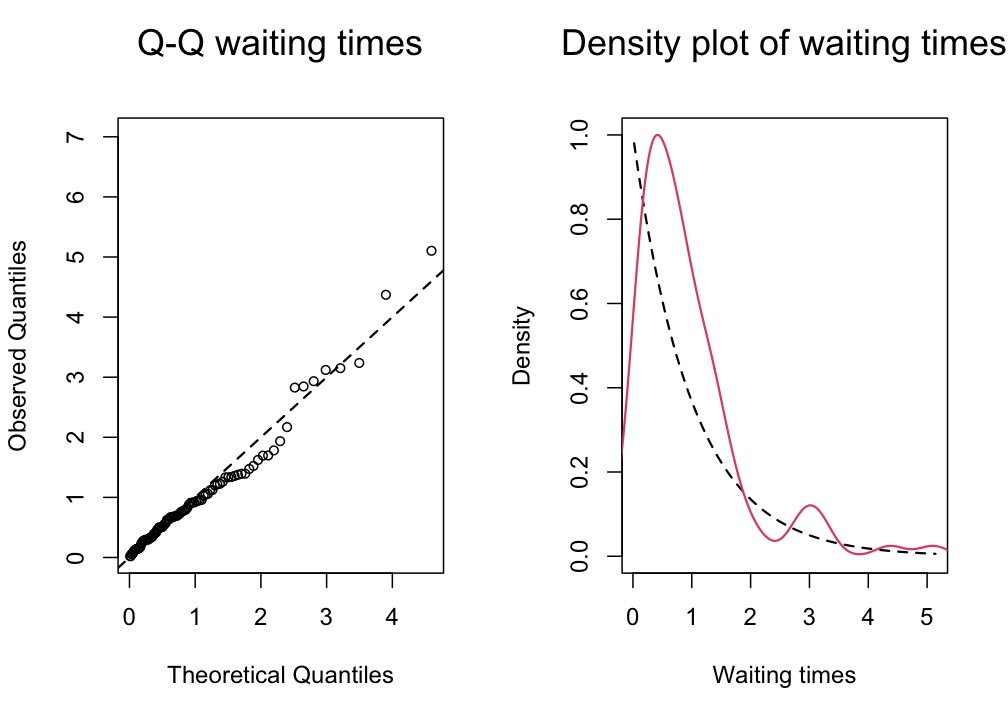

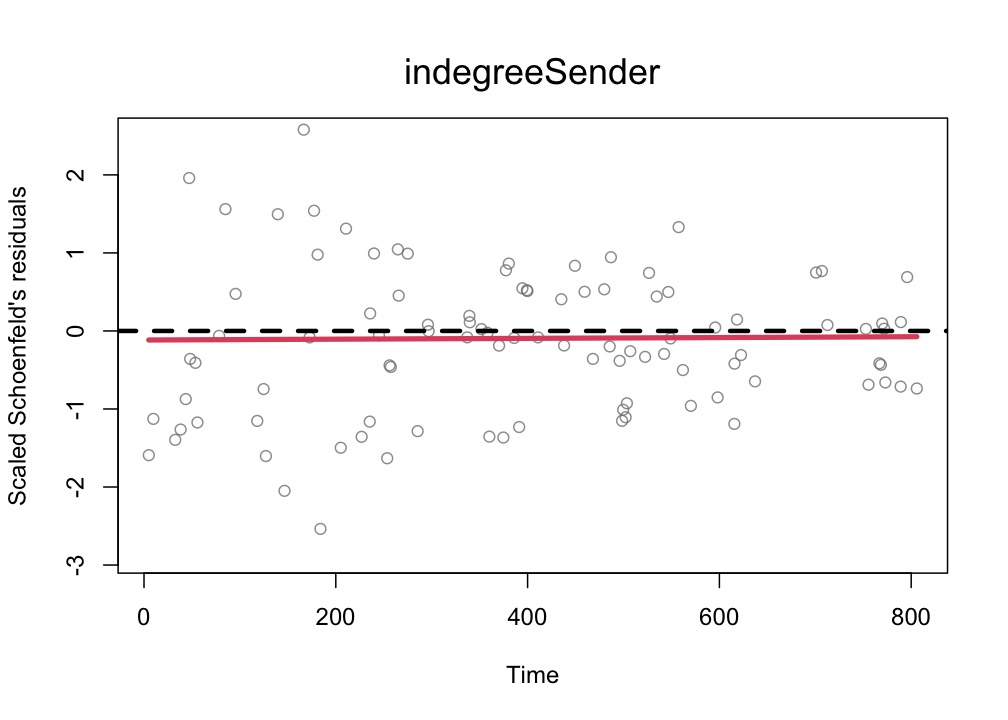

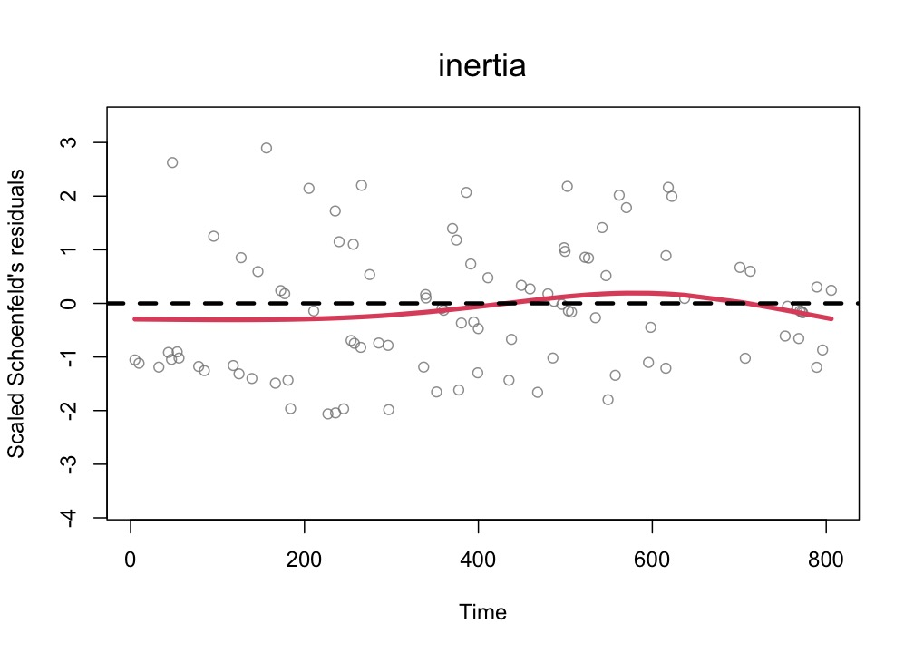

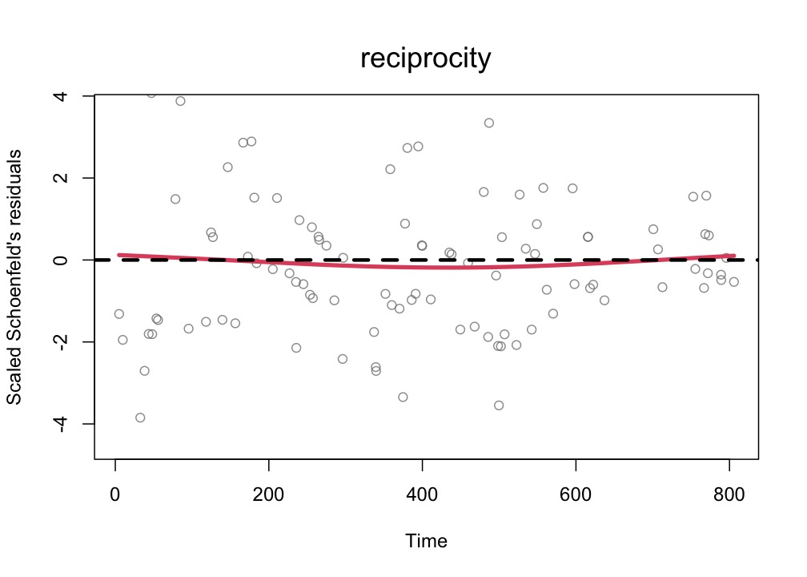

```r
# plot
plot(x = tie_mle, reh  = tie_reh, diagnostics = tie_mle_diagnostics)
```

### *Bayesian* approach

#### **Hamiltonian Monte Carlo (HMC)**

```r
tie_hmc <- remstimate::remstimate(reh = tie_reh,
                        stats =  tie_stats,
                        method = "HMC",
                        ncores = ncores,
                        nsim = 200L, # 200 draws to generate per each chain
                        nchains = 2L, # 2 chains to generate
                        burnin = 200L, # burnin length is 200
                        thin = 2L, # thinning size set to 2 (the final length of the chains will be 100)
                        seed = 23029, # set a seed only for reproducibility purposes
                        WAIC = TRUE, # setting WAIC computation to TRUE
                        nsimWAIC = 100 # number of draws for the computation of the WAIC set to 100
                        )

# summary
summary(tie_hmc)
```

```
## Relational Event Model (tie oriented)
##
## Call:
## ~1 + remstats::indegreeSender() + remstats::inertia() + remstats::reciprocity()
##
##
## Posterior Modes (HMC with interval likelihood):
##
##                  Post.Mode     Post.SD       Q2.5%        Q50%  Q97.5% Pr(=0|x)
## baseline       -4.9738e+00  1.0244e-01 -5.1298e+00 -4.9498e+00 -4.7421  < 2e-16
## indegreeSender  4.7209e-02  2.2185e-02  2.9913e-05  4.4926e-02  0.0853  0.50835
## inertia        -1.7753e-01  5.2532e-02 -2.8617e-01 -1.9470e-01 -0.0945  0.03189
## reciprocity    -6.7931e-02  5.2635e-02 -1.3849e-01 -4.7775e-02  0.0763  0.81225
## Log posterior: -600.4316
```

`Q2.5%`, `Q50%` and `Q97.5%` are respectively the percentile 2.5, the median (50th percentile) and the percentile 97.5.

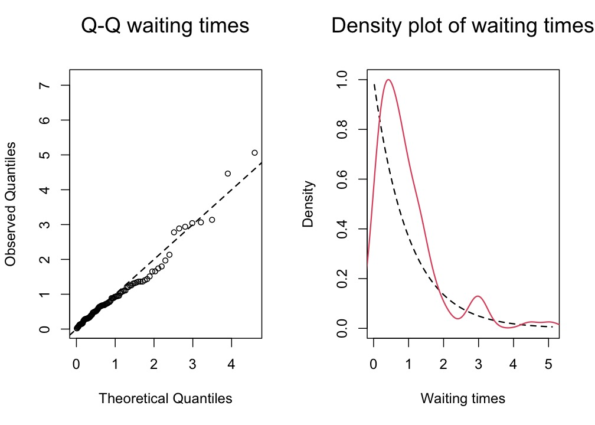

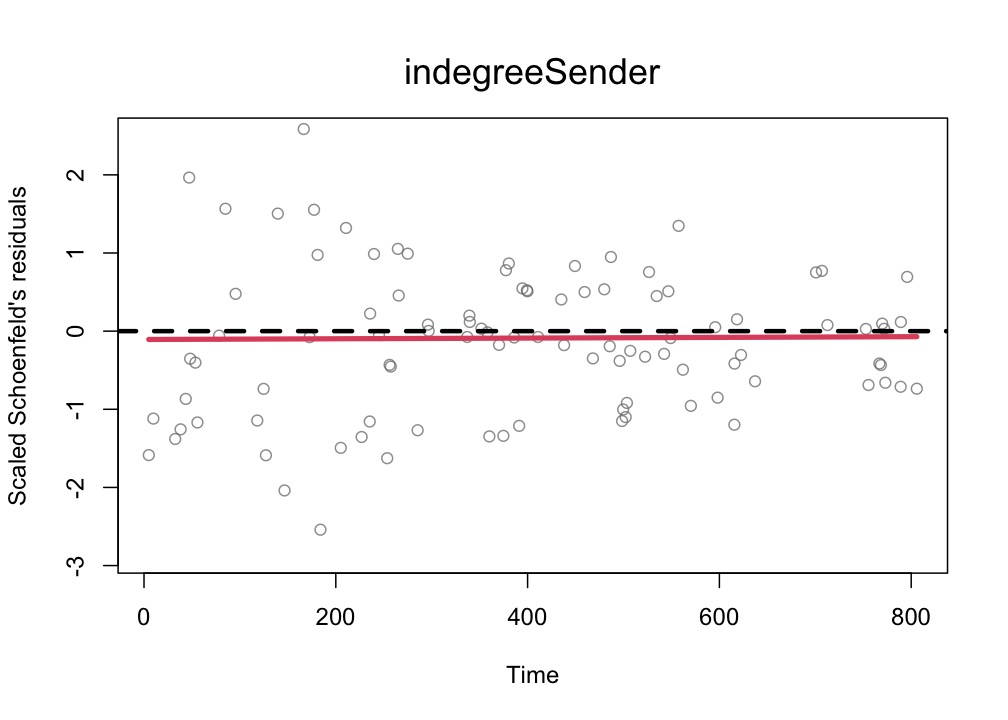

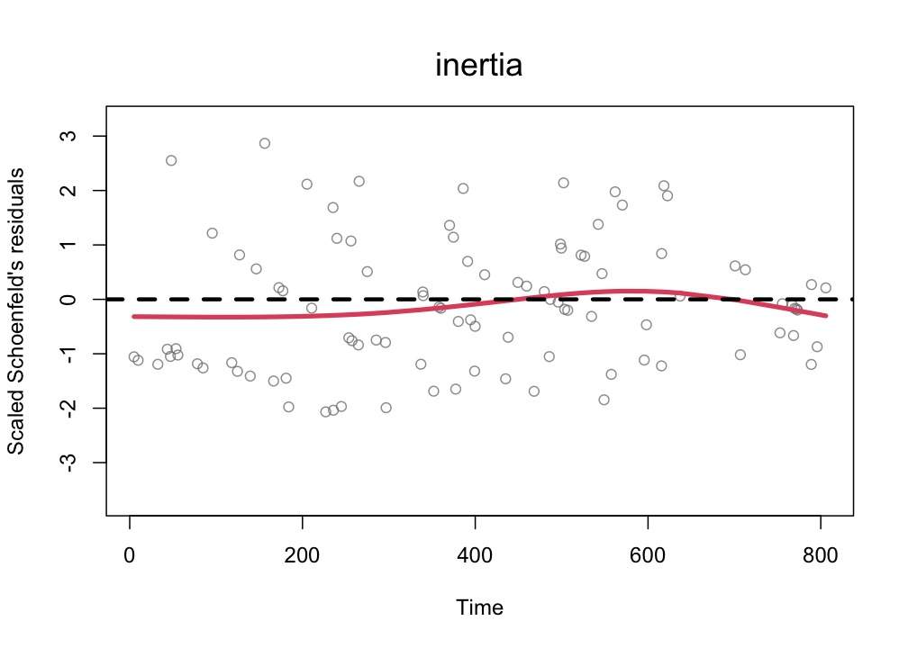

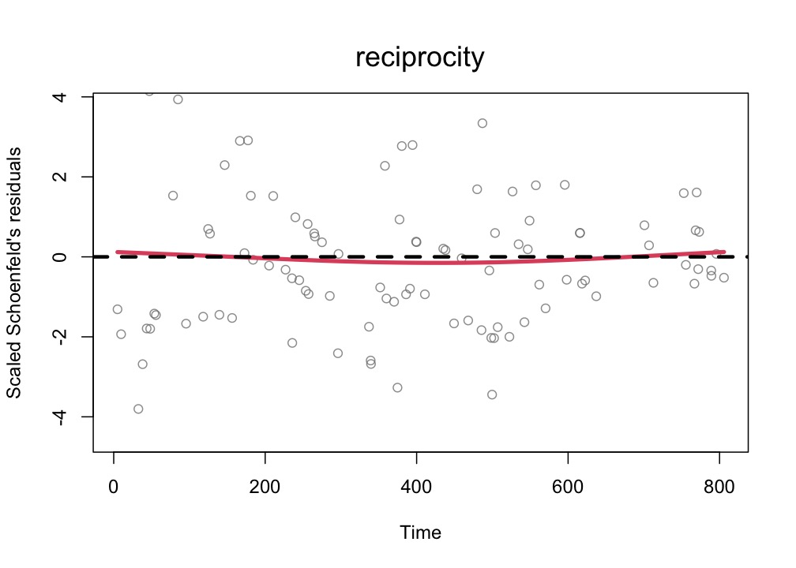

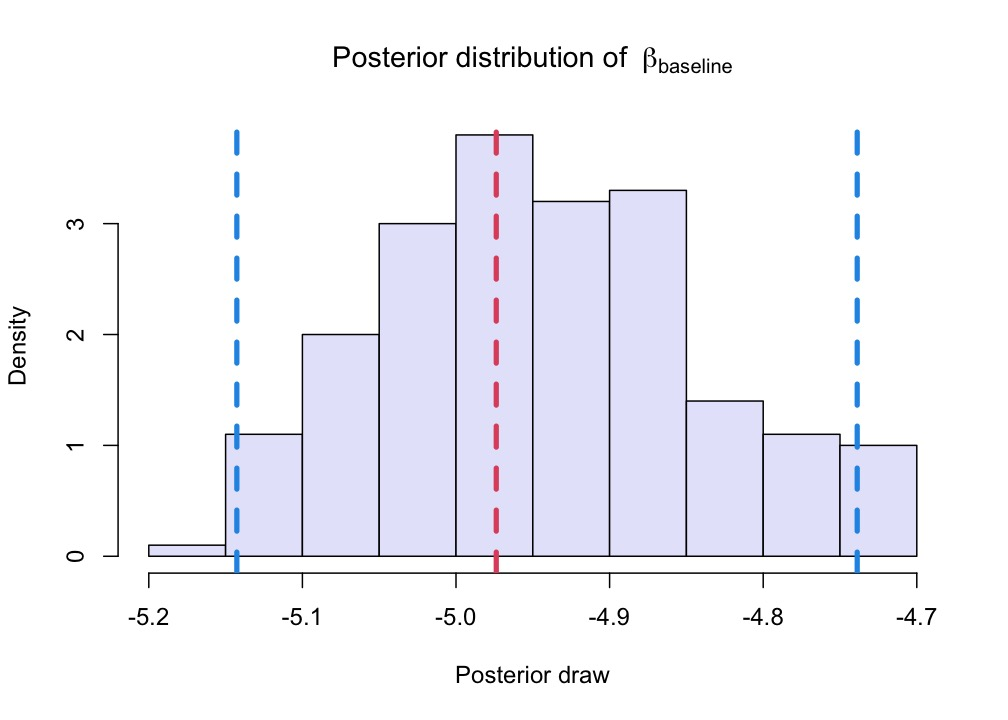

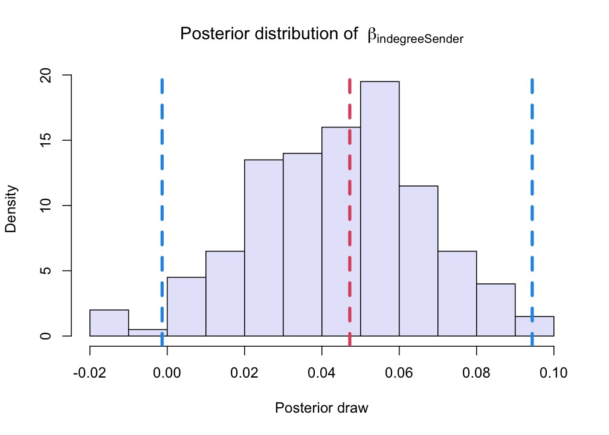

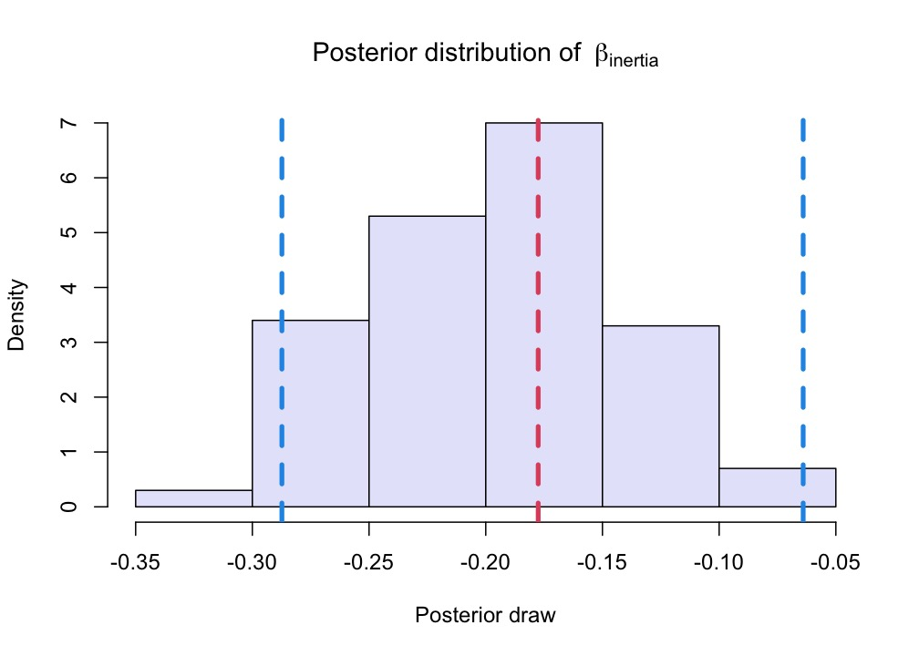

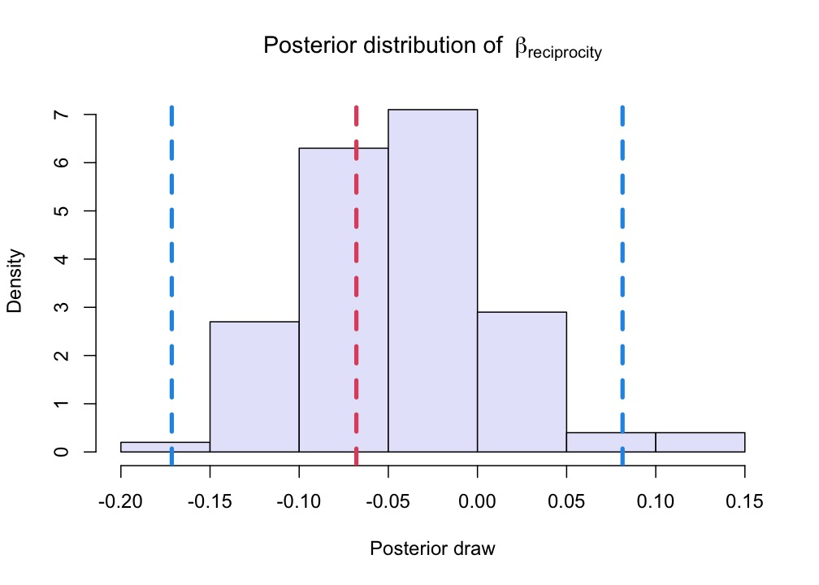

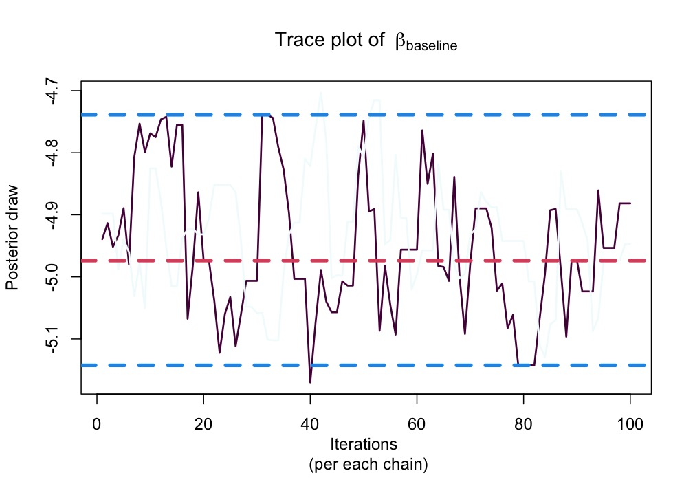

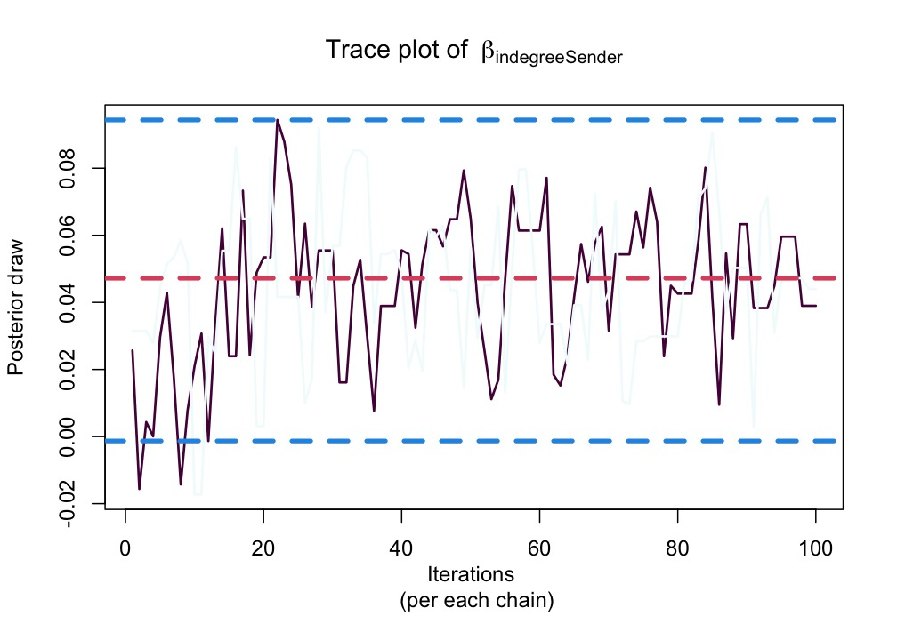

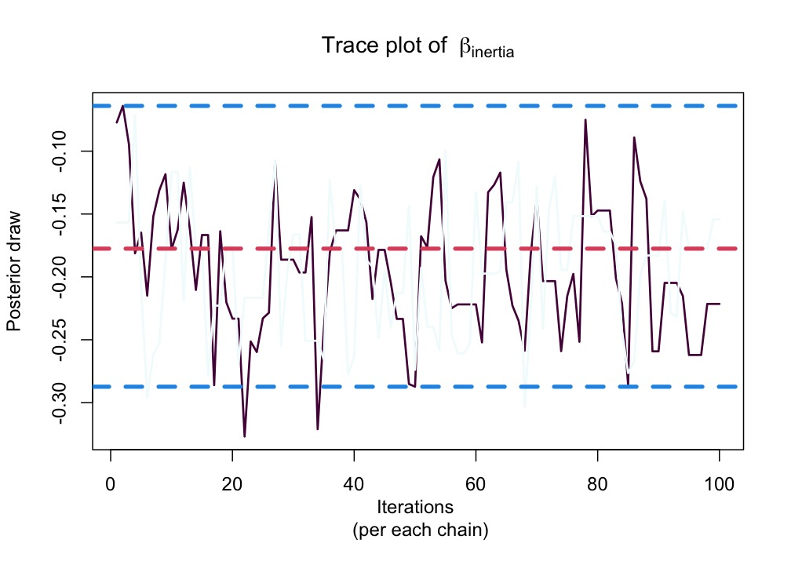

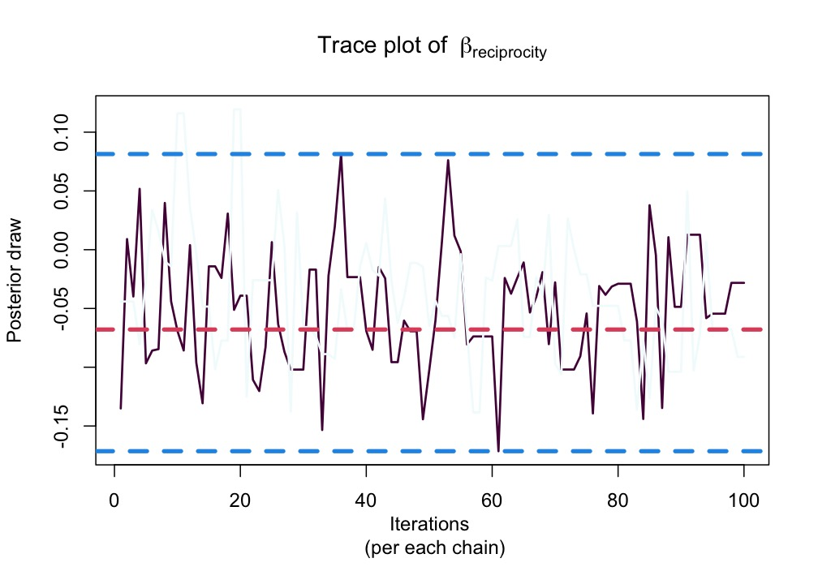

```r
# diagnostics
tie_hmc_diagnostics <- diagnostics(object = tie_hmc, reh = tie_reh, stats = tie_stats)
# plot (histograms and trace plot have highest posterior density intervals dashed lines in blue and posterior estimate in red)
plot(x = tie_hmc, reh  = tie_reh, diagnostics = tie_hmc_diagnostics)
```

## Actor-Oriented Modeling framework

For the actor-oriented modeling, we refer the modeling framework introduced by Stadtfeld and Block (2017), in which the process of realization of a relational event is described by two steps:

1. first the actor that is going to initiate the next interaction and becomes the “sender” of the future event;
2. then the choice of the “receiver” of the future event operated by the active “sender” in step 1.

The first step is modelled via a rate model (similar to a REM), in which the waiting times are modelled along with the sequence of the senders of the observed relational events. The second step is modelled via a multinomial discrete choice model, where we model the choice of the receiver of the next event conditional to the active sender at the first step.

Therefore, the two models can be described by two separate likelihood functions with their own set of parameters. The parameters in each model will describe the effect that explanatory variables (network dynamics and other available exogenous statistics) have on the two distinct processes. The estimation of the model parameters for each model can be carried out separately and for this reason, the user can also provide a `remstats` object containing the statistics of either both or one of the two models.

### The likelihood function

Consider a time-ordered sequence of $M$ relational events, $E_{t_M}=(e_1,\ldots,e_M)$, where each event $e_{m}$ in the sequence is described by the 3-tuple $(s_{m},r_{m},t_{m})$ (we exclude here the information about the event type), respectively sender, receiver, and time of the event. Furthermore, consider $N$ to be the number of actors in the network. For simplicity, we assume that all actors in the network can be the sender or the receiver of a relational event (i.e. *full* risk set, see `vignette(topic="riskset",package="remify")` for more information on alternative definitions of the risk set) and we use the index $n$ to indicate any actor in the set $\mathcal{R}$ of actors at risk, thus $n \in \left\lbrace 1,2,\ldots,N\right\rbrace$.

#### Sender activity rate model

The likelihood function that models the sender activity is:

$$\mathscr{L}_{\text{sender
model}}(\boldsymbol{\theta}; E_{t_M},X)=
\prod_{m=1}^{M}{\Bigg[\tau(s_{m},t_{m},\boldsymbol{\theta})\prod_{n \in
\mathcal{R}}^{}{\exp{\left\lbrace-\tau(n,t_{m},\boldsymbol{\theta})\left(t_m-t_{m-1}\right)\right\rbrace}
}}\Bigg]$$

where:

- $\tau(n,t_{m},\boldsymbol{\theta})$ is the activity rate of sender $n$ at time $t_{m}$. The sender activity rate describes the istantaneous probability that a sender initiates an interaction at a specific time point and it is modeled as $\tau(n,t_{m},\boldsymbol{\theta}) = \exp{\left\lbrace \boldsymbol{\theta}^{T}X_{[m,n,.]}\right\rbrace}$ where:
  - $\boldsymbol{\theta}$ is the vector of parameters of interest. Such parameters describe the effect that the sufficient statistics (explanatory variables) have on the activity rate of the sender;
  - $\boldsymbol{\theta}^{T}X_{[m,n,.]} = \sum_{p=1}^{P}{\theta_p X_{[m,n,p]}}$ is the linear predictor of the sender $n$ at time $t_{m}$. The object $X$ is a three dimensional array with number of rows equal to the number of unique time points (or events) in the sequence (see `vignette(package="remstats")` for more information about statistics calculated *per unique time point* or *per observed event*), number of columns equal to number of actors in the sequence ($N$), number of slices equal to the number of variables in the linear predictor ($P$).
- $s_m$ refers to the sender of the event observed at time $t_m$ and $n$ refers to any actor that can be sender of an interaction at time $t_m$;
- $\mathcal{R}$ describes the set of actors at risk of initiating an interaction, becoming then the future sender of a relational event (the set also includes the actor that is sender of the event at time $t_m$). In this tutorial, the risk set of the sender model is assumed to be the *full* risk set, where all the actors in the network can be “the sender” of a relational event at any time point in the event sequence;
- $(t_{m}-t_{m-1})$ is the waiting time between two subsequent relational events.

If the time of occurrence of the events is not available and we know only their order of occurrence, then the likelihood function for the sender model reduces to the Cox proportional-hazard survival model (Cox 1972),

$$\mathscr{L}_{\text{sender
model}}(\boldsymbol{\theta}; E_{t_M},X)=
\prod_{m=1}^{M}{\Bigg[\frac{\tau(s_{m},t_{m},\boldsymbol{\theta})}{\sum_{n\in
\mathcal{R}}^{}{\tau(n,t_{m},\boldsymbol{\theta})}}}\Bigg]$$

#### Receiver choice model

The likelihood function that models the receiver choice is:

$$\mathscr{L}_{\text{receiver
model}}(\boldsymbol{\beta};
E_{t_M},X)=\prod_{m=1}^{M}{\Bigg[\frac{\exp{\left\lbrace\boldsymbol{\beta}^{T}U_{[m,r_m,.]}\right\rbrace}}{\sum_{n
\in \mathcal{R} \setminus \left\lbrace s_m \right\rbrace
}^{}{\exp{\left\lbrace\boldsymbol{\beta}^{T}U_{[m,n,.]}\right\rbrace}}}\Bigg]}$$

where:

- $\exp{\left\lbrace\boldsymbol{\beta}^{T}U_{[m,r_m,.]}\right\rbrace} \backslash \sum_{n \in \mathcal{R} \setminus \left\lbrace s_m \right\rbrace }^{}{\exp{\left\lbrace\boldsymbol{\beta}^{T}U_{[m,n,.]}\right\rbrace}}$ is the conditional probability that the sender $s_m$ active at time $t_m$ chooses $r_m$ as the receiver of the next interaction, and:
  - $\boldsymbol{\beta}$ is the vector of $K$ parameters of interest. Such parameters describe the effect that the sufficient statistics (explanatory variables) have on the choice of a receiver;
  - $\boldsymbol{\beta}^{T}U_{[m,n,.]} = \sum_{k=1}^{K}{\beta_k U_{[m,n,k]}}$ is the linear predictor of the event at time $t_{m}$ in which the sender is $s_m$ and the receiver is any of the possible receivers, $n$ with $n \neq s_m$. The object $U$ is a three dimensional array with number of rows equal to the number of events in the sequence (see `vignette(package="remstats")` for more information about statistics calculated *per unique time point* or *per observed event*), number of columns equal to number of actors ($N$), number of slices equal to the number of variables in the linear predictor ($K$).
- $r_m$ refers to the receiver observed at time $t_m$ and $n$ refers to any actor that can be the receiver of the event at time $t_m$ (excluding the sender at time $t_m$)
- $\mathcal{R}$ describes the set of actors at risk of becoming the receiver of the next interaction. In the case of the receiver model, the risk set composition *changes* over time because at each time point the actor that is currently the sender cannot be also the receiver of the interaction and is excluded from the set of potential receivers. In this tutorial, the risk set of the reiceiver model is assumed to be the *full* risk set where all actors (excluding the current sender at each time point) can be “the receiver” at any time point.

#### A toy example on the actor oriented modeling framework

Consider the data `ao_data`, that is a list containing a simulated relational event sequence where events were generated by following the two-steps process described in the section above. We are going to model the sender activity rate and the receiver choice as:

$$\tau(n,t_{m},\boldsymbol{\theta}) =
\exp{\left\lbrace \theta_{\text{intercept}} +
\theta_{indegreeSender}\text{indegreeSender}(n,t_{m})\right\rbrace}$$

$$\exp{\left\lbrace
\boldsymbol{\beta}^{T}U_{[m,n,.]} \right\rbrace} = \exp{\left\lbrace
\beta_{\text{inertia}}\text{inertia}(s_m,n,t_{m}) +
\beta_{\text{reciprocity}}\text{reciprocity}(s_m,n,t_{m})\right\rbrace}$$

Furthermore, we know that *true* parameters quantifying the effect of the *statistics* (name in subscript next to the model parameters $\theta$ and $\beta$) used in the generation of the event sequence are:

- for the sender model,
  $$\begin{bmatrix}
  \theta_{intercept} \\ \theta_{\text{indegreeSender}} \end{bmatrix} =
  \begin{bmatrix} -5.0 \\ 0.01 \end{bmatrix}$$
- for the receiver model
  $$\begin{bmatrix} \beta_{\text{inertia}} \\
  \beta_{\text{reciprocity}} \end{bmatrix} = \begin{bmatrix} -0.1 \\
  0.03\end{bmatrix}$$

The parameters are also available as object within the list, `ao_data$true.pars`.

```r
# setting `ncores` to 1 (the user can change this parameter)
ncores <- 1L

# loading data
data(ao_data)

# true parameters' values
ao_data$true.pars
```

```
## $rate_model
##      intercept indegreeSender
##          -5.00           0.01
##
## $choice_model
##     inertia reciprocity
##       -0.10        0.03
```

```r
# processing event sequence with 'remify'
ao_reh <- remify::remify(edgelist = ao_data$edgelist, model = "actor")

# summary of the relational event network
summary(ao_reh)
```

```
## Relational Event Network
## (processed for actor-oriented modeling):
##  > events = 100
##  > actors = 5
##  > (event) types = 1
##  > riskset = full
##  > sender model riskset: 5 / 5 actors
##  > receiver model riskset: 4 receivers per sender
##  > directed = TRUE
##  > ordinal = FALSE
##  > weighted = FALSE
##  > time length ~ 2689
##  > interevent time
##       >> minimum ~ 0.8542
##       >> maximum ~ 167.3494
```

#### Estimating a model with `remstimate()` in 3 steps

The estimation of a model can be summarized in three steps:

1. First, we define the linear predictor with the variables of interest, using the statistics available within `remstats` (statistics calculated by the user can be also supplied to `remstats::remstats()`).

```r
# specifying linear predictor (for rate and choice model, with `remstats`)
rate_model <- ~ 1 + remstats::indegreeSender()
choice_model <- ~ remstats::inertia() + remstats::reciprocity()
```

2. Second, we calculate the statistics defined in the linear predictor with the function `remstats::remstats()` from the `remstats` package.

```r
# calculating statistics (with `remstats`)
ao_stats <- remstats::remstats(reh = ao_reh, sender_effects = rate_model, receiver_effects = choice_model)

# the actor-oriented 'remstats' object
ao_stats
```

```
## Relational Event Network Statistics
## > Model: actor-oriented
## > Computation method: per time point
## > Sender model:
##   >> Dimensions: 99 time points x 5 actors x 2 statistics
##   >> Statistics:
##       >>> 1: baseline
##       >>> 2: indegreeSender
## > Receiver model:
##   >> Dimensions: 99 events x 5 actors x 2 statistics
##   >> Statistics:
##       >>> 1: inertia
##       >>> 2: reciprocity
```

3. Finally, we are ready to run any of the optimization methods with the function `remstimate::remstimate()`.

```r
# for example the method "MLE"
remstimate::remstimate(reh = ao_reh,
                          stats =  ao_stats,
                          method = "MLE",
                          ncores = ncores)
```

```
## Relational Event Model (actor oriented)
##
## Coefficients rate model **for sender**:
##
##       baseline indegreeSender
##   -4.838760102   -0.005995972
##
## Null deviance: 1167.764
## Residual deviance: 1167.623
## AIC: 1171.623 AICC: 1171.748 BIC: 1176.813
##
## ---------------------------------------------------------------------------------------------------------------
##
## Coefficients choice model **for receiver**:
##
##     inertia reciprocity
## -0.03250836  0.01828749
##
## Null deviance: 274.4863
## Residual deviance: 274.2826
## AIC: 278.2826 AICC: 278.4076 BIC: 283.4728
```

In the sections below, as already done with the tie-oriented framework, we show the estimation of the parameters using both available methods and we also show the usage and output of the methods available for a `remstimate` object.

### *Frequentist* approach

#### **Maximum Likelihood Estimation (MLE)**

```r
ao_mle <- remstimate::remstimate(reh = ao_reh,
                        stats = ao_stats,
                        ncores = ncores,
                        method = "MLE",
                        WAIC = TRUE, # setting WAIC computation to TRUE
                        nsimWAIC = 100) # number of draws for the computation of the WAIC set to 100
```

##### **print( )**

```r
# printing the 'remstimate' object
ao_mle
```

```
## Relational Event Model (actor oriented)
##
## Coefficients rate model **for sender**:
##
##       baseline indegreeSender
##   -4.838760102   -0.005995972
##
## Null deviance: 1167.764
## Residual deviance: 1167.623
## AIC: 1171.623 AICC: 1171.748 BIC: 1176.813 WAIC: 1171.391
##
## ---------------------------------------------------------------------------------------------------------------
##
## Coefficients choice model **for receiver**:
##
##     inertia reciprocity
## -0.03250836  0.01828749
##
## Null deviance: 274.4863
## Residual deviance: 274.2826
## AIC: 278.2826 AICC: 278.4076 BIC: 283.4728 WAIC: 278.4401
```

#### **summary( )**

```r
# summary of the 'remstimate' object
summary(ao_mle)
```

```
## Relational Event Model (actor oriented)
##
## Call rate model **for sender**:
##
##  ~1 + remstats::indegreeSender()
##
##
## Coefficients rate model (MLE with interval likelihood):
##
##                  Estimate   Std. Err    z value Pr(>|z|) Pr(=0)
## baseline        -4.838760   0.185118 -26.138826   0.0000 <2e-16
## indegreeSender  -0.005996   0.015982  -0.375175   0.7075 0.9027
## Null deviance: 1167.764 on 99 degrees of freedom
## Residual deviance: 1167.623 on 97 degrees of freedom
## Chi-square: 0.1414688 on 2 degrees of freedom, asymptotic p-value 0.9317093
## AIC: 1171.623 AICC: 1171.748 BIC: 1176.813 WAIC: 1171.391
## ---------------------------------------------------------------------------------------------------------------
##
## Call choice model **for receiver**:
##
##  ~remstats::inertia() + remstats::reciprocity()
##
##
## Coefficients choice model (MLE with interval likelihood):
##
##              Estimate  Std. Err   z value Pr(>|z|) Pr(=0)
## inertia     -0.032508  0.077037 -0.421983   0.6730 0.9010
## reciprocity  0.018287  0.071630  0.255305   0.7985 0.9059
## Null deviance: 274.4863 on 99 degrees of freedom
## Residual deviance: 274.2826 on 97 degrees of freedom
## Chi-square: 0.2037334 on 2 degrees of freedom, asymptotic p-value 0.90315
## AIC: 278.2826 AICC: 278.4076 BIC: 283.4728 WAIC: 278.4401
```

#### **Information Criteria**

```r
# AIC
AIC(ao_mle)
```

```
##   sender model receiver model
##      1171.6227       278.2826
```

```r
# AICC
AICC(ao_mle)
```

```
##   sender model receiver model
##      1171.7477       278.4076
```

```r
# BIC
BIC(ao_mle)
```

```
##   sender model receiver model
##      1176.8130       283.4728
```

```r
# WAIC
WAIC(ao_mle)
```

```
##   sender model receiver model
##      1171.3908       278.4401
```

#### **diagnostics( )**

```r
# diagnostics
ao_mle_diagnostics <- diagnostics(object = ao_mle, reh = ao_reh, stats = ao_stats)
```

#### **plot( )**

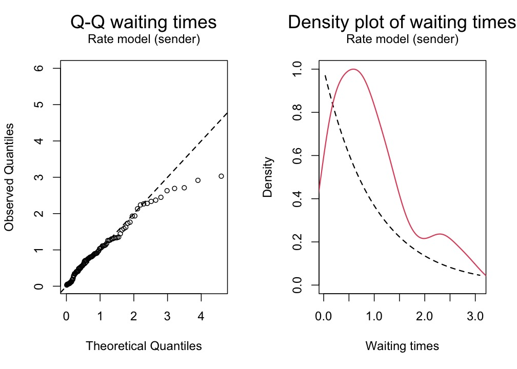

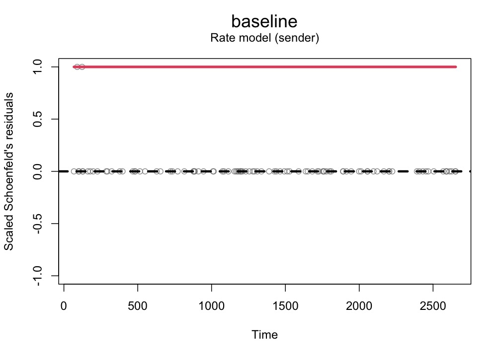

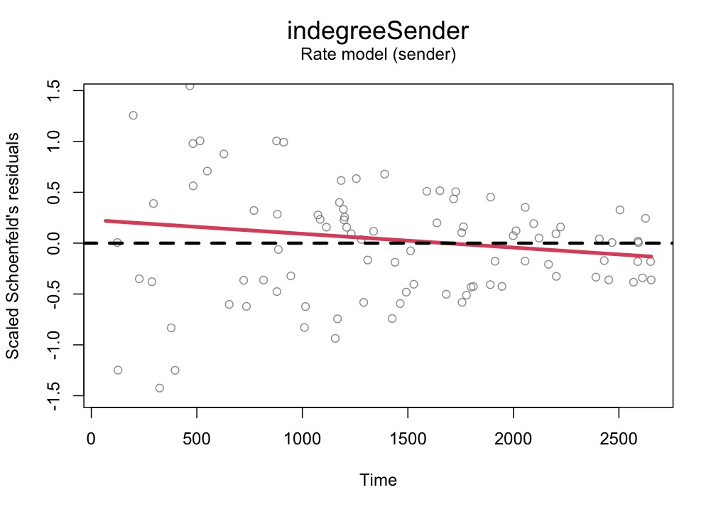

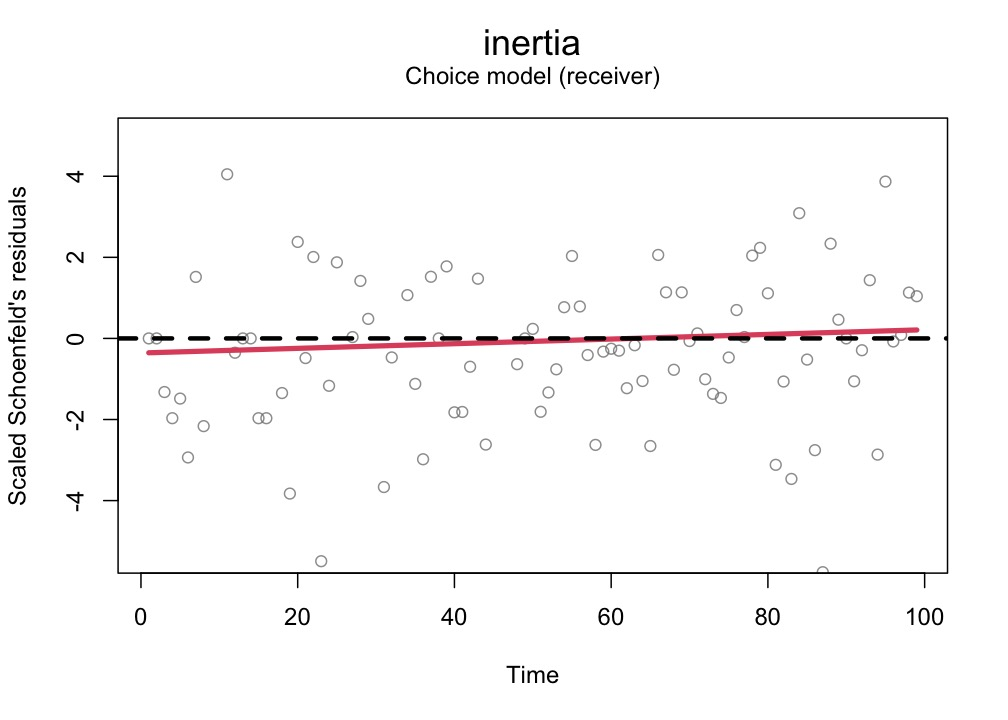

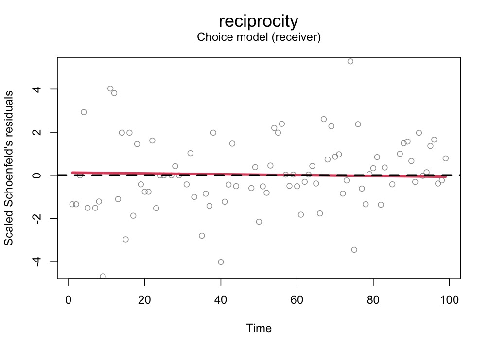

```r
# plot
plot(x = ao_mle, reh  = ao_reh, diagnostics = ao_mle_diagnostics)
```

### *Bayesian* approach

#### **Hamiltonian Monte Carlo (HMC)**

```r
ao_hmc <- remstimate::remstimate(reh = ao_reh,
                        stats =  ao_stats,
                        method = "HMC",
                        ncores = ncores,
                        nsim = 300L, # 300 draws to generate per each chain
                        nchains = 2L, # 2 chains (each one long 200 draws) to generate
                        burnin = 300L, # burnin length is 300
                        L = 100L, # number of leap-frog steps
                        epsilon = 0.1/100, # size of a leap-frog step
                        thin = 2L, # thinning size (this will reduce the final length of each chain will be 150)
                        seed = 23029, # set a seed only for reproducibility purposes
                        WAIC = TRUE, # setting WAIC computation to TRUE
                        nsimWAIC = 100 # number of draws for the computation of the WAIC set to 100
                        )

# summary
summary(ao_hmc)
```

```
## Relational Event Model (actor oriented)
##
## Call rate model **for sender**:
##
##  ~1 + remstats::indegreeSender()
##
##
## Posterior Modes rate model (HMC with interval likelihood):
##
##                 Post.Mode    Post.SD      Q2.5%       Q50%  Q97.5% Pr(=0|x)
## baseline       -4.8522814  0.1154292 -5.0455567 -4.8246585 -4.6134   <2e-16
## indegreeSender -0.0047507  0.0098748 -0.0237661 -0.0060711  0.0117   0.8986
## Log posterior: -583.9322
## ---------------------------------------------------------------------------------------------------------------
##
## Call choice model **for receiver**:
##
##  ~remstats::inertia() + remstats::reciprocity()
##
##
## Posterior Modes choice model (HMC with interval likelihood):
##
##              Post.Mode    Post.SD      Q2.5%       Q50% Q97.5% Pr(=0|x)
## inertia     -0.0331986  0.0429158 -0.1187147 -0.0231174 0.0489   0.8806
## reciprocity  0.0192208  0.0417183 -0.0703949 -0.0012063 0.0862   0.8995
## Log posterior: -137.1414
```